# Single-cell RNAseq of mouse heart development

03 January, 2020

### Batch correction

We begin with the good-quality, normalised data produced in the `01_QC_and_normalisation.Rmd` script.

```r
## sce object
sce <- readRDS(paste0(dir, "data/sce_goodQual.NORM.Rds"))
```

Now we need to check for batch effects. For this, we begin by visualising the data in low dimensional space, with UMAP.

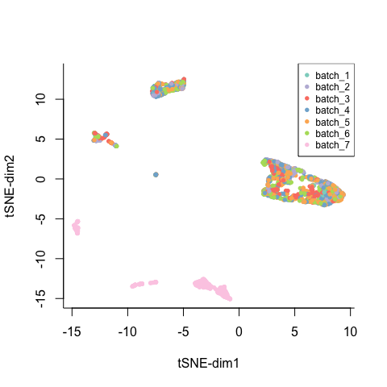

```r
set.seed(497)
sce <- runUMAP(sce)

umap <- as.data.frame(reducedDim(sce, "UMAP"))
colnames(umap) <- c("x", "y")
write.table(umap, paste0(dir,"results/umapCoords.tab"), quote=FALSE, sep="\t")

## colour by batch
umap$batch <- sce$batch
## randomise order per batch
tmp <- umap[sample(row.names(umap), nrow(umap), replace = FALSE),]
plot(tmp$x, tmp$y, pch=16, cex=0.75, col=tmp$batch, xlab="tSNE-dim1", ylab="tSNE-dim2", bty="l")
legend("topright", legend = levels(tmp$batch), col=1:7, pch=16, cex=0.75)
```

To correct the batch effects we use the method proposed by Haghverdi et al. (*Nature Biotechnology*, 2018), based on mutual nearest neighbours (MNNs), but use the quicker implementation in `fastMNN`.

We restrict the calculations to highly varaible genes, defined using the method proposed by Brennecke et al. (*Nature Meethods*, 2015). We retain the 2000 genes with largest variation, but remove any mitochondrial and sexually dimorphic genes.

```r
hvgs <- modelGeneCV2(sce, block=sce$batch)
# plot(hvgs$mean, hvgs$total, log="xy", col=ifelse(hvgs$FDR<0.05, 'red', 'black'))
# points(hvgs$mean, hvgs$trend, col="blue", pch=16, cex=0.5)

hvgs <- getTopHVGs(hvgs, var.field="ratio", n=2000)

## we remove mitochondrial and sexually dimorphic genes from the list of HVGs
remove <- rowData(sce)[rowData(sce)$chr %in% c("Y", "MT"),]
remove <- rbind(remove, rowData(sce)[rowData(sce)$gene=='Xist',])

hvgs <- setdiff(hvgs, row.names(remove))
write.table(hvgs, file=paste0(dir, "results/HVGs_minMean1_FDR0.05.tsv"), quote = FALSE, col.names = FALSE, row.names = FALSE)
```

For batch correction, the order of the batches is important; we should use as *reference* the most diverse batch, to ensure cells in other batches are able to find their MNNs. We use the number of different stages per batch as a proxy for diversity.

```r
## The order of the batches alters the final result. The batch with greatest diversity
## should be used as reference (first) to maximise the chances of finding MNNs.
## Assuming that batches with more stages have more diversity...
# table(sce$batch, sce$stage)
#          -1   0   1   2   3 LHT
# batch_1   0   0   0   0   0  40
# batch_2   0   0   0 159   0 133
# batch_3   0 173 117   0   0   0
# batch_4   0   0  71 262 320   0
# batch_5   0   0 328 227 124   0
# batch_6   0   0 313 302   0   0
# batch_7 227 309   0   0   0   0

## specifiy which cells corrspond to which batch; levels indicate the order for merging
batch <- factor(sce$batch, levels=paste0("batch_", c(5,4,6,3,2,7,1)))
sce.corr <- fastMNN(sce, batch=batch, subset.row = hvgs, correct.all = TRUE)
saveRDS(sce.corr, paste0(dir, "data/sce_goodQual.NORM.batchCorrected.Rds"))

dataCorr <- assay(sce.corr, "reconstructed")
saveRDS(dataCorr, file = paste0(dir, "data/heartData_unbiased.goodQual.NORM.batchCorrected.Rds"))
```

Finally, we visualise the corrected data.

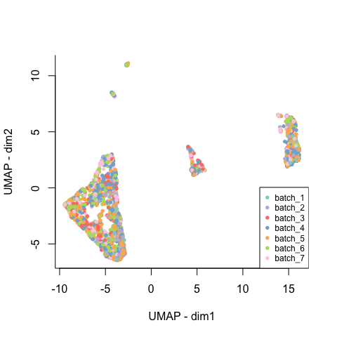

```r
## visualise corrected data, which is already cosine normalised
set.seed(8183)
sce.corr <- runUMAP(sce.corr, subset_row = hvgs, exprs_values = "reconstructed", n_neighbors=50, min_dist = 0.1)

umap <- as.data.frame(reducedDim(sce.corr, "UMAP"))
colnames(umap) <- c("x", "y")

## colour by batch
umap$batch <- sce$batch
## randomise order per batch
tmp <- umap[sample(row.names(umap), nrow(umap), replace = FALSE),]
plot(tmp$x, -1*tmp$y, pch=16, cex=0.75, col=tmp$batch, xlab="UMAP - dim1", ylab="UMAP - dim2", bty="l")
legend("bottomright", legend = levels(tmp$batch), col=1:7, pch=16, cex=0.75)
```

```r
## change y-coords for better visualisation
umap$y <- -1*umap$y
write.table(umap, paste0(dir,"results/umapCoords_corrected.tab"), quote=FALSE, sep="\t")
```

Cells from all batches are now well mixed and the clusters should reflect different biological populations.